# AN588 Final Replication Analysis

Cecelia Gerstenbacher

12/10/2021

# Decreasing seagrass density negatively influences associated fauna (McCloskey and Unsworth, 2015)

[]https://peerj.com/articles/1053/

Required packages:

```r
library(curl)
library(ggplot2)
library(forcats)
```

## Study Description:

Seagrasses are marine angiosperms which exist on all continents except Antarctica and often form dense monoculture meadows in shallow and calm coastal inlets. These dense meadows provide, among other things, habitat to a wide variety of marine organisms, many of which are endangered or commercially valuable. Unfortunately, seagrasses are experiencing rapid degradation, as anthropogenic threats such as trawling, dredging, and eutrophication have caused a tenfold decrease in seagrass cover over the last 40 years.

Locally, this degradation can look like a boat anchor dragging through a meadow, ripping up seagrass and reducing the plant, or “shoot” density in the vicinity. This subsequently reduces the complexity of the habitat. Because complex habitats provide more hide space for juveniles and vulnerable prey, a reduction in this complexity is theorized to reduce the density and diversity of ecosystem associated fauna, even on small scales. To test the hypothesis that a local decrease in seagrass density will negatively impact associatef fauna, this study collected motile fauna samples using seine net hauls from six 6x6 meter seagrass plots from the same meadow over a gradient of varying habitat characteristics, including seagrass percent cover and shoot density. They recorded each animal in each siene net haul. They then repeated this for ten 6x6 seagrass plots at the same location the subsequent year.

In order to statistically confirm if there is a difference in faunal density and diversity between high and low cover plots the following analyses were employed

##### - Summary stats (means, standard deviations, frequencies)

##### - ANOSIM (analysis of similarity)

##### - Shannon Weiner Diversity Index

##### - Non-metric Multidimensional scaling (nMDS) with superimposed Bray Curtis Clusters

##### - Percentage Similarity Contributions

##### - Spearmans Rank Correlations

For the purposes of this assignment, we will be replicating the ANOSIM and Spearmans Rank Correlations. Further, we will replicate all summary statistics, and create a figure showing the mean fish abundance per seine haul for 8 high and 8 low cover plots, including standard deviation.

## Getting started

### Loading data and collecting summary stats

First, lets load and explore the data.

```r
library(curl)
f<- curl ("https://raw.githubusercontent.com/ceceg27/ceceg27-data-replication-assignment/main/ceceg27_rawdata.csv")
d <- read.csv(f, header = TRUE, sep = ",", stringsAsFactors = FALSE)
head(d)
```

```
##            Cover                      X                        X.1 High High.1
## 1         Family                Species                       Name    1      2
## 2       Gobiidae Pomatoschistus minutus                  Sand goby    0      0
## 3       Labridae       Symphodus melops                   Corkwing    8      0
## 4 Gasterosteidae    Spinachia spinachia Fifteen-spined stickleback    1      0
## 5 Pleuronectidae  Pleuronectes platessa                     Plaice    0      0
## 6   Palaemonidae      Palaemon serratus               Common prawn   51     45
##   High.2 High.3 High.4 High.5 High.6 High.7 Low Low.1 Low.2 Low.3 Low.4 Low.5
## 1      3      4      5      6      7      8   1     2     3     4     5     6
## 2      0      0      0      0      0      0   0     0     0     0     0     0
## 3      2      1      4      1      2      1   0     0     0     0     0     0
## 4      1      0      1      1      0      2   1     1     0     0     0     0
## 5      0      0      0      0      1      0   2     7     2     0     1     3
## 6      2      3      3     22     77     15  20    68    10   107    92    53
##   Low.6 Low.7 X.2 X.3 X.4 X.5 X.6 X.7 X.8 X.9 X.10 X.11 X.12 X.13 X.14 X.15
## 1     7     8  NA  NA  NA  NA  NA  NA  NA  NA   NA   NA   NA   NA   NA   NA
## 2     1     0  NA  NA  NA  NA  NA  NA  NA  NA   NA   NA   NA   NA   NA   NA
## 3     0     0  NA  NA  NA  NA  NA  NA  NA  NA   NA   NA   NA   NA   NA   NA
## 4     0     0  NA  NA  NA  NA  NA  NA  NA  NA   NA   NA   NA   NA   NA   NA
## 5     1     2  NA  NA  NA  NA  NA  NA  NA  NA   NA   NA   NA   NA   NA   NA
## 6    12    35  NA  NA  NA  NA  NA  NA  NA  NA   NA   NA   NA   NA   NA   NA
##   X.16 X.17 X.18 X.19 X.20 X.21 X.22 X.23 X.24 X.25 X.26 X.27
## 1   NA   NA   NA   NA   NA   NA   NA   NA   NA   NA   NA   NA
## 2   NA   NA   NA   NA   NA   NA   NA   NA   NA   NA   NA   NA
## 3   NA   NA   NA   NA   NA   NA   NA   NA   NA   NA   NA   NA
## 4   NA   NA   NA   NA   NA   NA   NA   NA   NA   NA   NA   NA
## 5   NA   NA   NA   NA   NA   NA   NA   NA   NA   NA   NA   NA
## 6   NA   NA   NA   NA   NA   NA   NA   NA   NA   NA   NA   NA
```

The data set being used shows each family and species collected during the seine net samples, as well as its common name. It then shows the amount of this species collected for 8 high an 8 low seagrass density plots.

Unfortunately, in this format, data analysis is difficult. I have gone ahead and reformatted the excel file, and will upload it below, but I first wanted to show the original.

```r
library(curl)
f<- curl ("https://raw.githubusercontent.com/ceceg27/ceceg27-data-replication-assignment/main/meansandsd.csv")
d <- read.csv(f, header = TRUE, sep = ",", stringsAsFactors = FALSE)
head(d)
```

```
##   Pomatoschistus.minutus.low Pomatoschistus.minutus.high Symphodus.melops.high
## 1                          0                           0                     8
## 2                          0                           0                     0
## 3                          0                           0                     2
## 4                          0                           0                     1
## 5                          0                           0                     4
## 6                          0                           0                     1
##   Symphodus.melops.low Spinachia.spinachia.high Spinachia.spinachia.low
## 1                    0                        1                       1
## 2                    0                        0                       1
## 3                    0                        1                       0
## 4                    0                        0                       0
## 5                    0                        1                       0
## 6                    0                        1                       0
##   Pleuronectes.platessa.high Pleuronectes.platessa.low Palaemon.serratus.high
```

[output cut: 76 more lines]

```r
summary(d)
```

```
##  Pomatoschistus.minutus.low Pomatoschistus.minutus.high Symphodus.melops.high
##  Min.   :0.000              Min.   :0                   Min.   :0.000
##  1st Qu.:0.000              1st Qu.:0                   1st Qu.:1.000
##  Median :0.000              Median :0                   Median :1.500
##  Mean   :0.125              Mean   :0                   Mean   :2.375
##  3rd Qu.:0.000              3rd Qu.:0                   3rd Qu.:2.500
##  Max.   :1.000              Max.   :0                   Max.   :8.000
##  Symphodus.melops.low Spinachia.spinachia.high Spinachia.spinachia.low
##  Min.   :0            Min.   :0.00             Min.   :0.00
##  1st Qu.:0            1st Qu.:0.00             1st Qu.:0.00
##  Median :0            Median :1.00             Median :0.00
##  Mean   :0            Mean   :0.75             Mean   :0.25
##  3rd Qu.:0            3rd Qu.:1.00             3rd Qu.:0.25
##  Max.   :0            Max.   :2.00             Max.   :1.00
##  Pleuronectes.platessa.high Pleuronectes.platessa.low Palaemon.serratus.high
##  Min.   :0.000              Min.   :0.00              Min.   : 2.00
##  1st Qu.:0.000              1st Qu.:1.00              1st Qu.: 3.00
##  Median :0.000              Median :2.00              Median :18.50
##  Mean   :0.125              Mean   :2.25              Mean   :27.25
##  3rd Qu.:0.000              3rd Qu.:2.25              3rd Qu.:46.50
##  Max.   :1.000              Max.   :7.00              Max.   :77.00
##  Palaemon.serratus.low Crangon.crangon.high Crangon.crangon.low
##  Min.   : 10.00        Min.   :0.000        Min.   :0
##  1st Qu.: 18.00        1st Qu.:0.000        1st Qu.:0
##  Median : 44.00        Median :0.000        Median :0
##  Mean   : 49.62        Mean   :0.625        Mean   :0
##  3rd Qu.: 74.00        3rd Qu.:0.500        3rd Qu.:0
##  Max.   :107.00        Max.   :3.000        Max.   :0
##  Taurulus.bubalis.high Taurulus.bubalis.low Callionymus.lyra.high
##  Min.   :0.000         Min.   :0.00         Min.   :0.000
##  1st Qu.:0.000         1st Qu.:0.00         1st Qu.:0.000
##  Median :1.000         Median :0.00         Median :1.000
##  Mean   :0.625         Mean   :0.25         Mean   :0.875
##  3rd Qu.:1.000         3rd Qu.:0.25         3rd Qu.:1.250
##  Max.   :1.000         Max.   :1.00         Max.   :2.000
##  Callionymus.lyra.low Gobiusculus.flavescens.high Gobiusculus.flavescens.low
##  Min.   :0            Min.   :0.00                Min.   :0
##  1st Qu.:0            1st Qu.:0.00                1st Qu.:0
##  Median :0            Median :0.50                Median :0
##  Mean   :0            Mean   :0.75                Mean   :0
```

[output cut: 36 more lines]

```
##  Max.   :1.000        Max.   :0           Max.   :3.000     Max.   :5.00
##  Scyliorhinus.canicula.high Scyliorhinus.canicula.low Entelurus.aequoreus.high
##  Min.   :0.000              Min.   :0                 Min.   :0.00
##  1st Qu.:0.000              1st Qu.:0                 1st Qu.:0.00
##  Median :0.000              Median :0                 Median :0.00
##  Mean   :0.125              Mean   :0                 Mean   :0.25
##  3rd Qu.:0.000              3rd Qu.:0                 3rd Qu.:0.25
##  Max.   :1.000              Max.   :0                 Max.   :1.00
##  Entelurus.aequoreus.low
##  Min.   :0
##  1st Qu.:0
##  Median :0
##  Mean   :0
##  3rd Qu.:0
##  Max.   :0
```

This format allows us to get the means and standard deviations for each species, and for each genre of plot (low or high percent cover).

### Collecting meand and standard deviations

Here, the summary function provides us with each mean, but we want each mean to be saved as a variable, as well as each sd. Lets do that below.

```r
m1 <- mean(d$Pomatoschistus.minutus.low)
m1
```

```
## [1] 0.125
```

```r
sd1 <- sd(d$Pomatoschistus.minutus.low)
sd1
```

```
## [1] 0.3535534
```

```r
#this works well, time to do it with the rest of the data
m2 <- mean(d$Pomatoschistus.minutus.high)
sd2 <- sd (d$Pomatoschistus.minutus.high)
m3 <- mean(d$Symphodus.melops.high)
sd3 <- sd(d$Symphodus.melops.high)
m4 <- mean (d$Symphodus.melops.low)
sd4 <- sd(d$Symphodus.melops.low)
m5 <- mean(d$Spinachia.spinachia.high)
sd5 <- sd(d$Spinachia.spinachia.high)
m6 <- mean (d$Spinachia.spinachia.low)
sd6 <- sd(d$Spinachia.spinachia.low)
m7 <- mean(d$Pleuronectes.platessa.high)
sd7 <- sd(d$Pleuronectes.platessa.high)
m8 <- mean(d$Pleuronectes.platessa.low)
sd8 <- sd(d$Pleuronectes.platessa.low)
m9 <- mean(d$Palaemon.serratus.high)
sd9 <- sd(d$Palaemon.serratus.high)
m10 <- mean(d$Palaemon.serratus.low)
sd10 <- sd(d$Palaemon.serratus.low)
m11 <- mean (d$Crangon.crangon.high)
sd11 <- sd(d$Crangon.crangon.high)
m12 <- mean(d$Crangon.crangon.low)
sd12 <- sd(d$Crangon.crangon.low)
m13 <- mean(d$Taurulus.bubalis.high)
sd13 <-sd(d$Taurulus.bubalis.high)
m14 <- mean(d$Taurulus.bubalis.low)
sd14 <- sd(d$Taurulus.bubalis.low)
m15 <- mean(d$Callionymus.lyra.high)
sd15 <- sd(d$Callionymus.lyra.high)
m16 <- mean(d$Callionymus.lyra.low)
sd16 <- sd(d$Callionymus.lyra.low)
m17 <- mean(d$Gobiusculus.flavescens.high)
sd17 <- sd(d$Gobiusculus.flavescens.high)
m18 <- mean(d$Gobiusculus.flavescens.low)
sd18 <- sd(d$Gobiusculus.flavescens.low)
m19 <- mean(d$Clupea.harengus.high)
sd19 <- sd(d$Clupea.harengus.high)
m20 <- mean(d$Clupea.harengus.low)
sd20 <- sd(d$Clupea.harengus.low)
m21 <- mean(d$Centrolabrus.exoletus.high.)
sd21 <- sd(d$Centrolabrus.exoletus.high.)
m22 <- mean(d$Centrolabrus.exoletus.low.)
sd22 <- sd(d$Centrolabrus.exoletus.low.)
m23 <- mean(d$Labrus.bergylta.high)
sd23 <- sd(d$Labrus.bergylta.high)
m24 <- mean(d$Labrus.bergylta.low)
sd24 <- sd(d$Labrus.bergylta.low)
m25 <- mean(d$Pollachius.pollachius.high)
sd25 <- sd(d$Pollachius.pollachius.high)
m26 <- mean(d$Pollachius.pollachius.low)
sd26 <- sd(d$Pollachius.pollachius.low)
m27 <- mean(d$Atherina.prebyter.high)
sd27 <- sd(d$Atherina.prebyter.high)
m28 <- mean(d$Atherina.prebyter.low)
sd28 <- sd(d$Atherina.prebyter.low)
m29 <- mean(d$Syngnathus.acus.high)
sd29 <- sd(d$Syngnathus.acus.high)
m30 <- mean(d$Syngnathus.acus.low)
sd30 <- sd(d$Syngnathus.acus.low)
m31 <- mean(d$Ciliata.mustela.high)
sd31 <- sd(d$Ciliata.mustela.high)
m32 <- mean(d$Ciliata.mustela.low)
sd32 <- sd(d$Ciliata.mustela.low)
m33 <- mean(d$Gadus.morhua.high)
sd33 <- sd(d$Gadus.morhua.high)
m34 <- mean(d$Gadus.morhua.low)
sd34 <- sd(d$Gadus.morhua.low)
m35 <- mean(d$Scyliorhinus.canicula.high)
sd35 <- sd(d$Scyliorhinus.canicula.high)
m36 <- mean(d$Scyliorhinus.canicula.low)
sd36 <- sd(d$Scyliorhinus.canicula.low)
m37 <- mean(d$Entelurus.aequoreus.high)
sd37 <- sd(d$Entelurus.aequoreus.high)
m38 <- mean(d$Entelurus.aequoreus.low)
sd38 <- sd(d$Entelurus.aequoreus.low)
```

Ok that was painful and I’m sure there was a better way to do it but hey. Also its very frustrating to know how easy this would be in excel :(. Ok I’m gonna make all of these values into a vector so there aren’t a million means and sds floating around.

```r
means <- c(m1, m2, m3, m4, m5, m6, m7, m8, m9, m10, m11, m12, m13, m14, m15, m16, m17, m18, m19, m20, m21, m22, m23, m24, m25, m26, m27, m28, m29, m30, m31, m32, m33, m34, m35, m36, m37, m38)
means
```

```
##  [1]  0.125  0.000  2.375  0.000  0.750  0.250  0.125  2.250 27.250 49.625
## [11]  0.625  0.000  0.625  0.250  0.875  0.000  0.750  0.000  8.000  0.375
## [21]  0.125  0.000  0.625  0.000  7.250  5.625  0.625  1.250  0.375  0.000
## [31]  0.125  0.000  1.125  1.250  0.125  0.000  0.250  0.000
```

```r
sds <- c(sd1, sd2, sd3, sd4, sd5, sd6, sd7, sd8, sd9, sd10, sd11, sd12, sd13, sd14, sd15, sd16, sd17, sd18, sd19, sd20, sd21, sd22, sd23, sd24, sd25, sd26, sd27, sd28, sd29, sd30, sd31, sd32, sd33, sd34, sd35, sd36, sd37, sd38)
sds
```

```
##  [1]  0.3535534  0.0000000  2.5599944  0.0000000  0.7071068  0.4629100
##  [7]  0.3535534  2.1213203 27.6340887 36.8663125  1.1877349  0.0000000
## [13]  0.5175492  0.4629100  0.8345230  0.0000000  1.0350983  0.0000000
## [19] 17.2378321  0.5175492  0.3535534  0.0000000  0.9161254  0.0000000
## [25]  4.7734384  5.4494430  1.0606602  1.8322508  0.5175492  0.0000000
## [31]  0.3535534  0.0000000  1.2464235  1.8322508  0.3535534  0.0000000
## [37]  0.4629100  0.0000000
```

Nice, now we have means and sds which we can actually work with, and which match the means and sds in the data that the paper provided.

## Replicating the Figure

After lots of trials, I couldn’t figure out how to get the means and sds to segregate based on both species and percent cover in a ggplot. I think it would be much easier to just have these values in a csv. This is what the authors did (they just calculated mean and sd in excel before exporting the data for analysis). Sooooo, now that I’ve shown that I can get mean and sd in R, I’m going to create and import a new dataset, so I can properly segregate in my ggplot. These mean and ad vectors will become useful later anyway.

```r
library(curl)
f<- curl ("https://raw.githubusercontent.com/ceceg27/ceceg27-data-replication-assignment/main/ggplotdata.csv")
d <- read.csv(f, header = TRUE, sep = ",", stringsAsFactors = FALSE)
summary(d)
```

```
##    species          percent.cover           mean             sd
##  Length:36          Length:36          Min.   :0.000   Min.   : 0.000
##  Class :character   Class :character   1st Qu.:0.000   1st Qu.: 0.000
##  Mode  :character   Mode  :character   Median :0.300   Median : 0.500
##                                        Mean   :1.014   Mean   : 1.333
##                                        3rd Qu.:0.825   3rd Qu.: 1.125
##                                        Max.   :8.000   Max.   :17.200
```

```r
head(d)
```

```
##                  species percent.cover mean  sd
## 1 Pomatoschistus minutus         high   0.0 0.0
## 2 Pomatoschistus minutus           low  0.1 0.4
## 3       Symphodus melops         high   2.4 2.6
## 4       Symphodus melops           low  0.0 0.0
## 5    Spinachia spinachia         high   0.8 0.7
## 6    Spinachia spinachia           low  0.3 0.5
```

Ok now we can make the ggplot much easier.

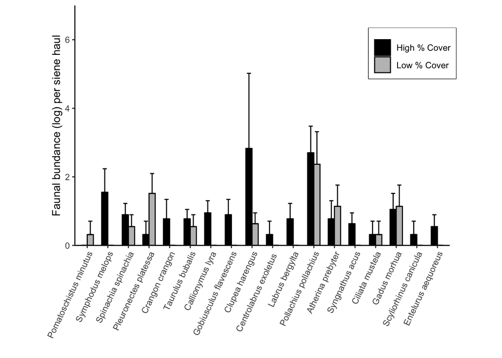

```r
p <-ggplot(d, aes(x=species, y=sqrt(mean), fill=percent.cover)) +
    geom_bar(position=position_dodge(),stat="identity", color = "black", width = .6) + #formatting bars
    geom_errorbar(aes(x = species, ymin=sqrt(mean), ymax=sqrt(mean + sd)),
                  width=.4,
                  position=position_dodge(width = .6))  # making the error bars
p <- p + scale_fill_manual(labels = c("High % Cover", "Low % Cover"), values = c(rep(c("black", "gray75"))))#adding color
p <- p + theme(legend.box.background = element_rect(color = "black",fill = "white"),legend.title=element_blank(), legend.position = c(.9,.8)) #making legend look like original
p <- p + theme(axis.line = element_line(colour = "black"),
    panel.grid.major = element_blank(),
    panel.grid.minor = element_blank(),
    panel.border = element_blank(),
    panel.background = element_blank()) #removing grid and gray background
p <- p + scale_y_continuous(expand = c(0.0,0.0),
                   limits = c(0.0,7)) #making graph start at 0
p <- p + theme(axis.text.x = element_text(angle = 65, vjust = 1, hjust=1)) + coord_equal(1/0.6) #adjusting x axis
library(forcats)
p <- p + aes(x = fct_inorder(species)) #reordering to match the source
p <- p + ylab("Faunal bundance (log) per siene haul") +xlab("") #label

p
```

Now lets compare it to the original:

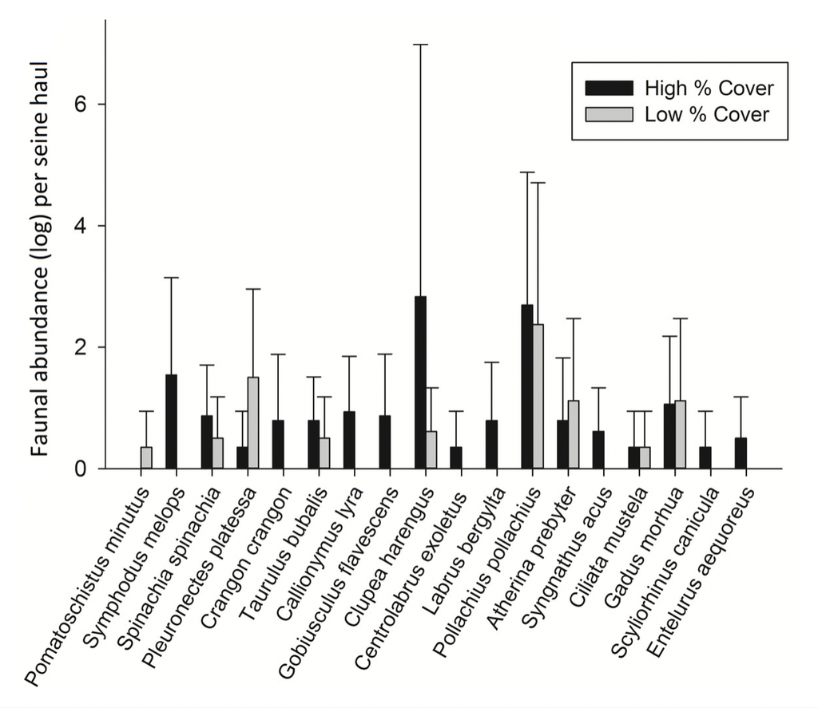

At this point, the bargraph is looking about 95% similar to the original, but I am still facing one problem.

The original bar graph says that the data was log transformed, however if I try to log transform this data it gives me negative numbers and completely messes up the graph. When I don’t transform the data, it gives me the same plot but to a different scale, with the y axis going up to 30. In the original plot the y axis goes up to 7. I began to think maybe they had done some other transformation on the data. I square rooted the means and sds and it gave me something very similar to the original graph. The means are now the same, but the sds look a little bit off. It would have been very beneficial if they reported exactly how they transformed the data to get it to scale.

Despite that, I’m pretty happy with how the graph turned out. It actually took forever to make what I originally thought would be a simple graph, but I did it.

Now lets get on to some more complex data analysis